# HM 878 Applied Biostatistics Problem Set #1a

## Descriptive Statistics, Confidence Intervals, 5-point Summary, Frequencies, Graphs

*Goals: This Problem Set will provide students with the opportunity to learn how to use R to conduct basic statistical tests, replicating many tests that were already done in HM 802. The main goal is to make sure you are familiar with R as a system for statistical analysis. You did these same analyses in HM 802, using the same datasets and SPSS. I’ve included SPSS output here so that you can check your work. You don’t have to conduct hypothesis tests. Include your output from R. If you are not getting the same information in R (it may be formatted differently or called a different thing and that is ok), you should keep trying. For now, I’m only interested in making sure you can use R to do these analyses.*

Analyses include:

- Descriptive statistics
- Frequency distributions
- Graphical displays of data

*Setting up the code environment*

```r
library(dplyr)
df = read.csv("C:\\Users\\ljens\\Downloads\\Anticonvulsants.csv")
head(df)
```

```
##   center_id center_size gender treatment week convulsions
## 1      7057           1      0         0    0           2
## 2      7057           1      0         0    1           6
## 3      7057           1      0         0    2           4
## 4      7057           1      0         0    3           4
## 5      7057           1      0         0    4           6
## 6      7057           1      0         0    5           3
```

## Question 1

Data: Anticonvulsants.csv. Variable: convulsions. Use R to calculate descriptive statistics: mean, median, mode, and standard deviation. Calculate quartiles. Calculate a 5-point summary and the upper and lower fences to determine outliers.

```r
summary(df$convulsions)
```

```
##    Min. 1st Qu.  Median    Mean 3rd Qu.    Max.
##   0.000   2.000   3.000   5.029   6.000  85.000
```

```r
mode_tbl = table(df$convulsions)
print(paste("Mode: ", substr(toString(names(mode_tbl[mode_tbl==max(mode_tbl)])), 1, 5)))
```

```
## [1] "Mode:  2"
```

```r
print(paste("Standard Deviation: ", substr(toString(sd(df$convulsions)), 1, 5)))
```

```
## [1] "Standard Deviation:  5.459"
```

```r
print(paste("IQR: ", substr(toString(IQR(df$convulsions)), 1, 5)))
```

```
## [1] "IQR:  4"
```

```r
print(paste("Upper Fence: ", substr(toString(quantile(df$convulsions, 0.75) + 1.5*IQR(df$convulsions)), 1, 5)))
```

```
## [1] "Upper Fence:  12"
```

```r
print(paste("Lower Fence: ", substr(toString(quantile(df$convulsions, 0.25) - 1.5*IQR(df$convulsions)), 1, 5)))
```

```
## [1] "Lower Fence:  -4"
```

## Question 2

Data: Anticonvulsants.csv. Variable: center size. Use R to create a frequency table.

```r
df <- df |> mutate(center_size_coded = recode(center_size, `1`="Small", `2`="Medium", `3`="Large" , .default = NA_character_))

table(df$center_size_code)
```

```
##
##  Large Medium  Small
##   1476   1320    594
```

## Question 3

Data: Cumulative Confirmed Cases and Deaths Among Confirmed Cases.csv. Use R to create a dual line graph showing confirmed COVID-19 Deaths and Cases on the same graph.

```r
df = read.csv("C:\\Users\\ljens\\Downloads\\Cumulative Confirmed Cases and Deaths Among Confirmed Cases.csv")
```

```r
head(df)
```

```
##       Date Cumulative_Cases Cumulative_Deaths
## 1 3/1/2020               14                 0
## 2 3/2/2020               27                 0
## 3 3/3/2020               49                 0
## 4 3/4/2020               73                 0
## 5 3/5/2020               99                 0
## 6 3/6/2020              141                 0
```

```r
colnames(df)
```

```
## [1] "Date"              "Cumulative_Cases"  "Cumulative_Deaths"
```

```r
library(tidyverse)
df = df |> mutate(Date = mdy(Date))
```

```r
head(df)
```

```
##         Date Cumulative_Cases Cumulative_Deaths
## 1 2020-03-01               14                 0
## 2 2020-03-02               27                 0
## 3 2020-03-03               49                 0
## 4 2020-03-04               73                 0
## 5 2020-03-05               99                 0
## 6 2020-03-06              141                 0
```

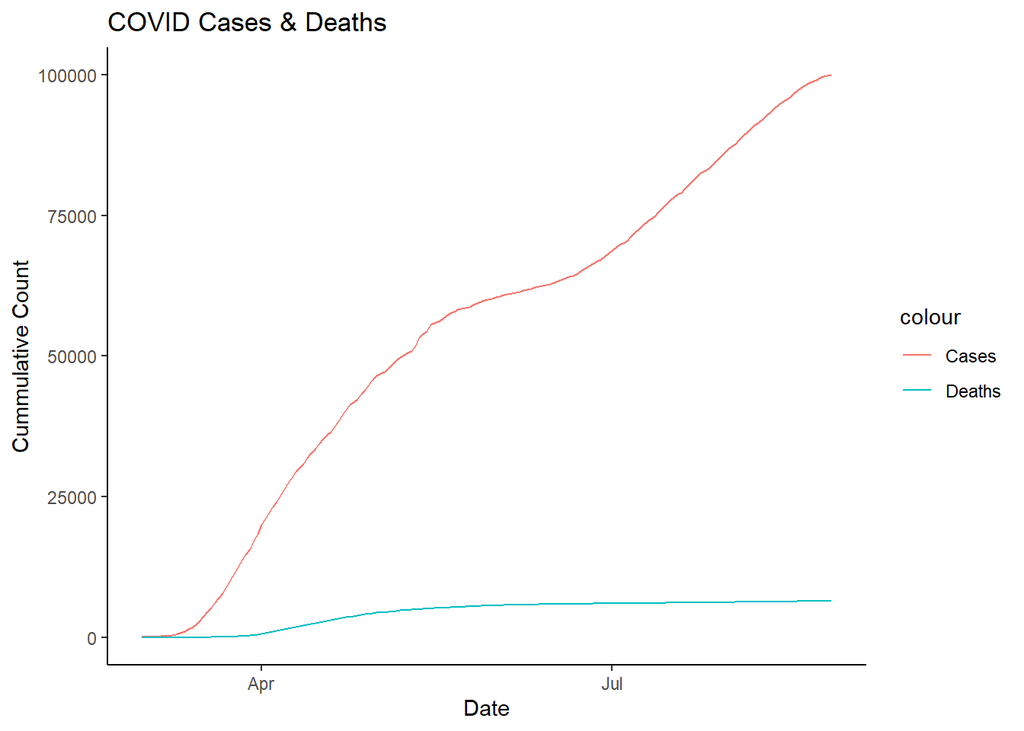

```r
ggplot(df, aes(Date)) +
  geom_line(aes(y=Cumulative_Cases, color = "Cases"), group=1)+
  geom_line(aes(y=Cumulative_Deaths, color="Deaths"), group=1) +
  labs(title="COVID Cases & Deaths", y="Cummulative Count", ) +
  ggplot2::theme_classic()
```

## Question 4

Data: COVID-19 Knowledge, Attitudes, and Behaviors.csv. Variable: Generations. Using R, Create a Pie Chart and Histogram.

```r
df = read.csv("C:\\Users\\ljens\\Downloads\\COVID-19 Knowledge, Attitudes, and Behaviors.csv")
```

```r
head(df$Generations)
```

```
## [1] "Baby Boomers" "Baby Boomers" "Baby Boomers" "Baby Boomers" "Baby Boomers"
## [6] "Baby Boomers"
```

```r
tbl = table(df$Generations)
```

```r
names(tbl)
```

```
## [1] "Baby Boomers" "Gen X"        "Gen Z"        "Millenials"
```

```r
tbl['Baby Boomers']
```

```
## Baby Boomers
##          104
```

```r
dd = df[c("Generations_1", 'Generations_2', 'Generations_3', 'Generations_4')]
```

```r
head(dd)
```

```
##   Generations_1 Generations_2 Generations_3 Generations_4
## 1             1             0             0             0
## 2             1             0             0             0
## 3             1             0             0             0
## 4             1             0             0             0
## 5             1             0             0             0
## 6             1             0             0             0
```

```r
df |> group_by(Generations) |> summarize(counts = length(Age))
```

```
## # A tibble: 4 × 2
##   Generations  counts
##   <chr>         <int>
## 1 Baby Boomers    104
## 2 Gen X           140
## 3 Gen Z            73
## 4 Millenials      717
```

```r
tbl = df |> group_by(Generations) |> summarize(counts = length(Age))
```

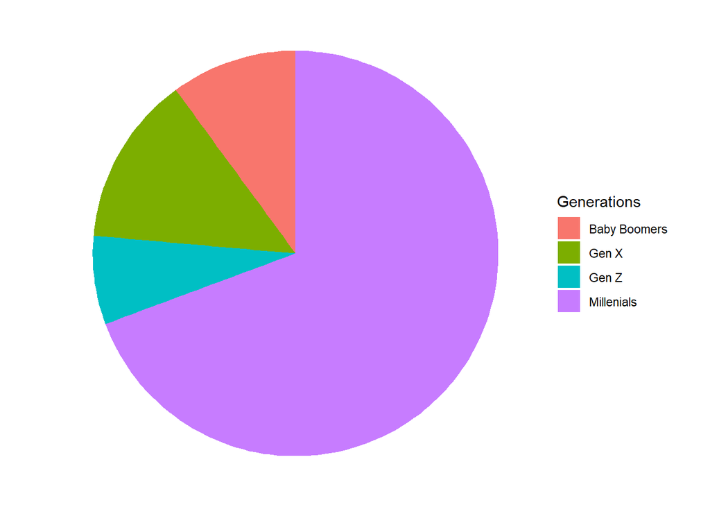

```r
ggplot(tbl, aes(x='', y=counts, fill=Generations)) +
  geom_bar(stat='identity', width=1) +
  coord_polar('y', start=0) +
  theme_void()
```

```r
tbl$Generations = factor(tbl$Generations, order = TRUE, levels = c('Baby Boomers','Gen X','Millenials','Gen Z'))
```

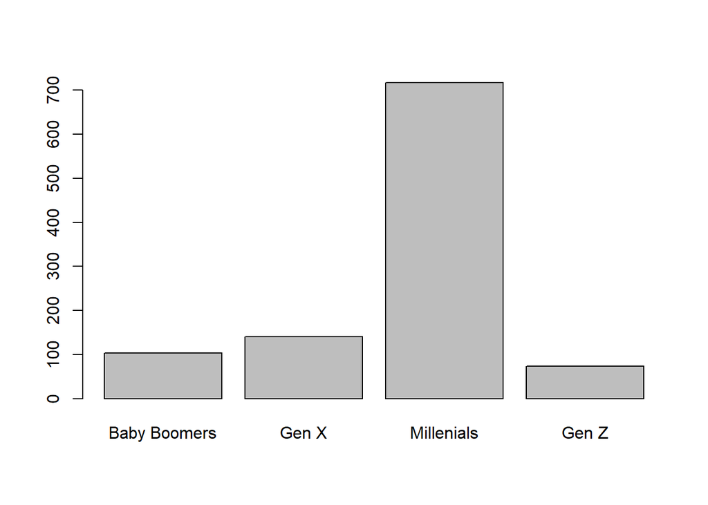

```r
plot(factor(df$Generations, order = TRUE, levels = c('Baby Boomers','Gen X','Millenials','Gen Z')))
```